# PSAT Week1 Package

KyounghyeonKo

2021 3 8

# CHAPTER 1. 전처리

## Q0. 기본 세팅

- 라이브러리 설치 (`plyr`, `tidyverse`, `data.table`)

```r
library(plyr)
library(tidyverse)
library(data.table)
```

- 경로설정, 데이터 불러오기

```r
setwd('C:/Users/RRR/Desktop/PSAT/Package/Week 1')
data = fread('data.csv')
```

## Q1. 데이터 확인하기

1. `str()`로 데이터 구조 확인

```r
str(data)
```

```
## Classes 'data.table' and 'data.frame':   5165 obs. of  8 variables:
##  $ patient_id    :integer64 1000000001 1000000002 1000000003 1000000004 1000000005 1000000006 1000000007 1000000008 ...
##  $ sex           : chr  "male" "male" "male" "male" ...
##  $ age           : chr  "50s" "30s" "50s" "20s" ...
##  $ country       : chr  "Korea" "Korea" "Korea" "Korea" ...
##  $ province      : chr  "서울" "서울" "서울" "서울" ...
##  $ city          : chr  "강서구" "중랑구" "종로구" "마포구" ...
##  $ confirmed_date: chr  "2020-01-23" "2020-01-30" "2020-01-30" "2020-01-30" ...
##  $ state         : chr  "released" "released" "released" "released" ...
##  - attr(*, ".internal.selfref")=<externalptr>
```

2. 각 열 별 `NA`개수 확인

```r
data %>% is.na %>% colSums
```

```
##     patient_id            sex            age        country       province
##              0              0              0              0              0
##           city confirmed_date          state
##              0              3              0
```

3. 각 열 별 `unique`값 및 개수 확인

```r
unique_data <- data %>%
                  select(-patient_id) %>%
                  apply(2,unique)

unique_data
```

```
## $sex
## [1] "male"   "female" ""
##
## $age
##  [1] "50s"  "30s"  "20s"  "60s"  "80s"  "70s"  "40s"  "10s"  "90s"  "0s"
## [11] ""     "100s"
##
## $country
##  [1] "Korea"          "China"          "United States"  "France"
##  [5] "Thailand"       "Canada"         "India"          "Switzerland"
##  [9] "Germany"        "Indonesia"      "Vietnam"        "Foreign"
## [13] "Mongolia"       "United Kingdom" "Spain"          "Bangladesh"
##
## $province
##  [1] "서울"     "부산"     "대구"     "광주"     "인천"     "대전"
```

[output cut: 67 more lines]

```r
#Check the number of unique values for each column
unique_data %>% lapply(length)
```

```
## $sex
## [1] 3
##
## $age
## [1] 12
##
## $country
## [1] 16
##
## $province
## [1] 17
##
## $city
## [1] 163
##
## $confirmed_date
## [1] 149
##
## $state
## [1] 3
```

## Q2-1. NA가 있는 행 삭제

```r
# 위에서 이미 confirmed_date 열에만 na가 있는 것을 알고 있으므로,
data <- data %>%
  filter(!is.na(confirmed_date))
```

## Q2-2.

1. 빈 문자열 `""`이 있는 행을 삭제

```r
#Remove rows with empty space
data <- data %>%
  filter(patient_id != "") %>%
  filter(sex != "") %>%
  filter(age != "") %>%
  filter(country != "") %>%
  filter(province != "") %>%
  filter(city != "") %>%
  filter(confirmed_date != "") %>%
  filter(state != "")
```

2. 다시 각 열마다 `NA` 개수 확인

```r
data %>% is.na %>% colSums
```

```
##     patient_id            sex            age        country       province
##              0              0              0              0              0
##           city confirmed_date          state
##              0              0              0
```

3. 다시 각 열마다 `unique`값 및 개수 확인

```r
unique_data <- data %>%
                  select(-patient_id) %>%
                  apply(2,unique)

unique_data
```

```
## $sex
## [1] "male"   "female"
##
## $age
##  [1] "50s"  "30s"  "20s"  "60s"  "80s"  "70s"  "40s"  "10s"  "90s"  "0s"
## [11] "100s"
##
## $country
##  [1] "Korea"          "China"          "United States"  "France"
##  [5] "Thailand"       "Canada"         "Switzerland"    "Germany"
##  [9] "Indonesia"      "Vietnam"        "Foreign"        "Mongolia"
## [13] "United Kingdom" "Spain"          "Bangladesh"
##
## $province
##  [1] "서울"     "부산"     "대구"     "인천"     "대전"     "경기도"
```

[output cut: 65 more lines]

```r
unique_data %>% lapply(length)
```

```
## $sex
## [1] 2
##
## $age
## [1] 11
##
## $country
## [1] 15
##
## $province
## [1] 16
##
## $city
## [1] 158
##
## $confirmed_date
## [1] 145
##
## $state
## [1] 3
```

## Q3. `country`열에 `'Korea'`인 행만 남기고 `country`열 삭제

```r
data <- data %>%
  filter(country=="Korea") %>%
  select(-country)
data %>%  head
```

```
##    patient_id    sex age province   city confirmed_date    state
## 1: 1000000001   male 50s     서울 강서구     2020-01-23 released
## 2: 1000000002   male 30s     서울 중랑구     2020-01-30 released
## 3: 1000000003   male 50s     서울 종로구     2020-01-30 released
## 4: 1000000004   male 20s     서울 마포구     2020-01-30 released
## 5: 1000000005 female 20s     서울 성북구     2020-01-31 released
## 6: 1000000006 female 50s     서울 종로구     2020-01-31 released
```

## Q4. `province`열 내 값 변경

```r
data$province <- data$province %>%
  revalue(c("서울"="서울특별시",
            "부산"="부산광역시",
            "대구"="대구광역시",
            "인천"="인천광역시",
            "대전"="대전광역시",
            "세종"="세종특별자치시",
            "울산"="울산광역시",
            "제주도"="제주특별자치도"))

data %>% head
```

```
##    patient_id    sex age   province   city confirmed_date    state
## 1: 1000000001   male 50s 서울특별시 강서구     2020-01-23 released
## 2: 1000000002   male 30s 서울특별시 중랑구     2020-01-30 released
## 3: 1000000003   male 50s 서울특별시 종로구     2020-01-30 released
## 4: 1000000004   male 20s 서울특별시 마포구     2020-01-30 released
## 5: 1000000005 female 20s 서울특별시 성북구     2020-01-31 released
## 6: 1000000006 female 50s 서울특별시 종로구     2020-01-31 released
```

## Q5. `confirmed_date`의 자료형을 날짜 자료형 `date`으로 변경

```r
data$confirmed_date <-
  data$confirmed_date %>% as.Date
str(data$confirmed_date)
```

```
##  Date[1:3653], format: "2020-01-23" "2020-01-30" "2020-01-30" "2020-01-30" "2020-01-31" ...
```

## Q6. 확진날짜 별 확진자 수에 대한 파생변수 `confirmed_number`생성

```r
#기존 데이터에 추가하는 것까지는 명확하게 몰라서 하지 않았습니다.
confirmed_number <- data %>%
  group_by(confirmed_date) %>%
  summarise(
    confirmed_number = n()
  )

confirmed_number %>% head
```

```
## # A tibble: 6 x 2
##   confirmed_date confirmed_number
##   <date>                    <int>
## 1 2020-01-23                    1
## 2 2020-01-26                    1
## 3 2020-01-27                    1
## 4 2020-01-30                    4
## 5 2020-01-31                    3
## 6 2020-02-02                    2
```

## Q7. 확진날짜의 주말, 주중 여부에 대한 파생변수 `wday` 생성

```r
wday <- data$confirmed_date %>%
  weekdays

wday <- ifelse(wday == "토요일" | wday == "일요일", "주말", "주중")


wday %>% head(10)
```

```
##  [1] "주중" "주중" "주중" "주중" "주중" "주중" "주중" "주말" "주중" "주중"
```

## Q8. 나이대 별 일별 확진자수에 대한 요약통계량

```r
confirmed_freq <- data %>%
  group_by(age, confirmed_date) %>%
  summarise(
    count = n()
  )
tapply(confirmed_freq$count, confirmed_freq$age, summary)
```

```
## $`0s`
##    Min. 1st Qu.  Median    Mean 3rd Qu.    Max.
##   1.000   1.000   1.000   1.488   2.000   3.000
##
## $`100s`
##    Min. 1st Qu.  Median    Mean 3rd Qu.    Max.
##       1       1       1       1       1       1
##
## $`10s`
##    Min. 1st Qu.  Median    Mean 3rd Qu.    Max.
##   1.000   1.000   2.000   2.276   3.000   8.000
##
## $`20s`
##    Min. 1st Qu.  Median    Mean 3rd Qu.    Max.
##   1.000   1.000   3.500   7.526  11.000  43.000
##
## $`30s`
##    Min. 1st Qu.  Median    Mean 3rd Qu.    Max.
##   1.000   2.000   3.000   5.051   8.000  17.000
##
## $`40s`
##    Min. 1st Qu.  Median    Mean 3rd Qu.    Max.
##   1.000   1.000   2.000   4.931   6.000  33.000
##
## $`50s`
##    Min. 1st Qu.  Median    Mean 3rd Qu.    Max.
##   1.000   1.000   3.000   6.112   9.000  31.000
##
## $`60s`
##    Min. 1st Qu.  Median    Mean 3rd Qu.    Max.
##   1.000   1.000   3.000   4.722   7.000  22.000
##
## $`70s`
##    Min. 1st Qu.  Median    Mean 3rd Qu.    Max.
##   1.000   1.000   2.000   2.908   3.250  13.000
##
## $`80s`
##    Min. 1st Qu.  Median    Mean 3rd Qu.    Max.
##   1.000   1.000   2.000   3.019   3.750  24.000
##
## $`90s`
##    Min. 1st Qu.  Median    Mean 3rd Qu.    Max.
##   1.000   1.000   1.000   2.286   2.000  16.000
```

# CHAPTER 2. 시각화

## Q1. Line plot(1)

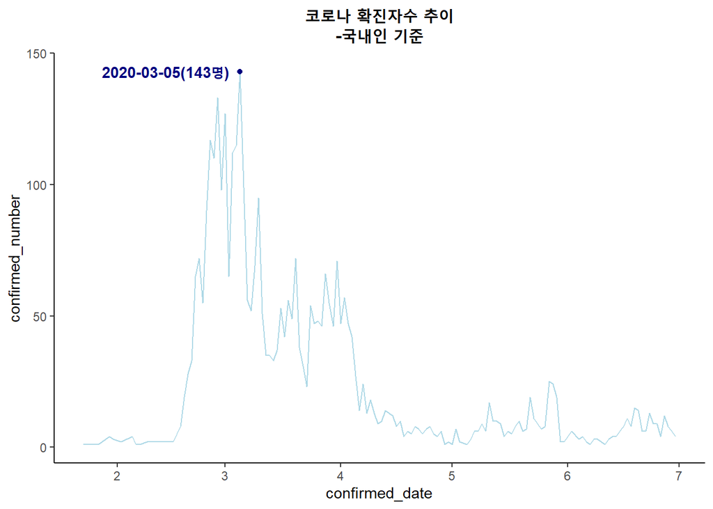

```r
#최대 확진자수가 발생한 날짜와 그날의 확진자수 생성
maximum <- data %>%
  group_by(confirmed_date) %>%
  summarise(
    confirmed_number = n()
  ) %>%
  mutate(
    max_index = which.max(confirmed_number),
    max_date = confirmed_date[max_index],
    max_num = confirmed_number[max_index]
  ) %>%
  select(max_date, max_num) %>%
  head(1)

#날짜별 확진자수 추이를 confirmed_number 이용하여 시각화 및 최대 확진자수 및 발생 날짜 표시
#챕터1 문제6에서 만든 confirmed_number를 직접 사용하지는 않았지만,
#아래 코드 내에서 문제 6번에서 했던 것과 동일하게 confirmed_number를 생성하여 이용했습니다.

data %>%
  group_by(confirmed_date) %>%
  summarise(
    confirmed_number = n()
  ) %>%
 ggplot(aes(confirmed_date, confirmed_number)) +
  geom_line(color = "lightblue") +
  annotate("point",
           x= maximum$max_date, y=maximum$max_num,
           color = 'navy') +
  annotate("text",
           x = maximum$max_date-20, y=maximum$max_num,
           label = sprintf("%s(%d명)", maximum$max_date, maximum$max_num),
           fontface = 2,
           color = 'navy') +
  labs(title="코로나 확진자수 추이\n-국내인 기준") +
  theme_classic() +
  theme(plot.title = element_text(hjust=0.5, face = "bold"))
```